# Initial Analysis - a run through the process

First, there are likely some cities that are kind of outliers from everything else. I think these could be ‘megacities’, though ’megacities are > 10,000,000 population. Let’s see anyway.

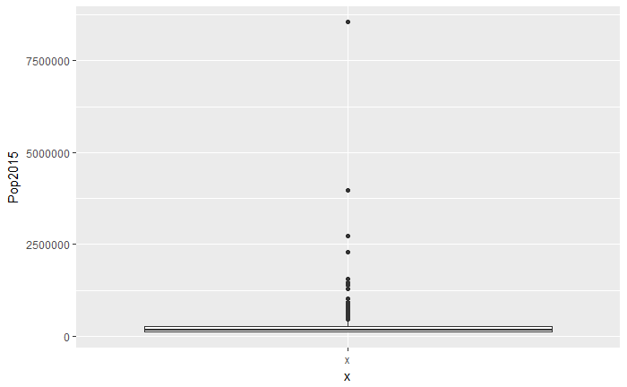

```r
city %>% ggplot(aes(x = "x",Pop2015)) + geom_boxplot()
```

None over 10 million in the city, but 2 million+ starts to get out there.

```r
city %>% filter(Pop2015 > 2000000) %>% dplyr::select(city_st)
```

| city_st |
| --- |
| Los Angeles_CA |
| Chicago_IL |
| New York_NY |
| Houston_TX |

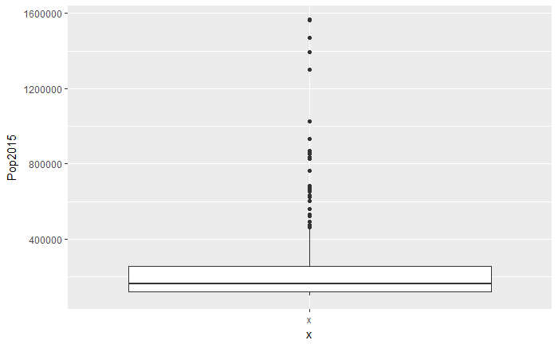

```r
city%>% filter(Pop2015 < 2000000) %>% ggplot(aes(x = "x",Pop2015)) + geom_boxplot()
```

Initially I will carry on with these, but will investigate how things are if they are excluded later.

### Correlation Only

The focus is on how greenspace and crime are related. First we’ll just see how they are correlated. The analysis will use only violent crime initially, then once the process if wored out we can do property crime.

```r
cor.test(df$CRMCYPERC, df$ndvi_mean_cbg_adj)
```

```
    Pearson's product-moment correlation

data:  df$CRMCYPERC and df$ndvi_mean_cbg_adj
t = 3.1535, df = 62084, p-value = 0.001614
alternative hypothesis: true correlation is not equal to 0
95 percent confidence interval:
 0.004789712 0.020519150
sample estimates:
       cor
0.01265521
```

```r
cor.test(df_urban$CRMCYPERC, df_urban$ndvi_mean_cbg_adj)
```

```
    Pearson's product-moment correlation

data:  df_urban$CRMCYPERC and df_urban$ndvi_mean_cbg_adj
t = 4.5952, df = 61181, p-value = 4.333e-06
alternative hypothesis: true correlation is not equal to 0
95 percent confidence interval:
 0.01065224 0.02649440
sample estimates:
       cor
0.01857448
```

Straight up violent crime and NDVI in block groups are correlated at 0.013. Positive but not strong at all. Urban block groups are only slightly higher.

### Linear Regression

Though it is not the proper way to approach the data, we’ll start with linear regression since that is how all of the books do it.

```r
mod_1a <- lm(CRMCYPERC ~ ndvi_mean_cbg_adj, data = df)
mod_1b <- lm(CRMCYPERC ~ ndvi_mean_cbg_adj, data = df_urban)
screenreg(list(mod_1a, mod_1b))
```

```
=============================================
                   Model 1       Model 2
---------------------------------------------
(Intercept)          177.63 ***    175.88 ***
                      (1.88)        (1.91)
ndvi_mean_cbg_adj      1.37 **       2.03 ***
                      (0.43)        (0.44)
---------------------------------------------
R^2                    0.00          0.00
Adj. R^2               0.00          0.00
Num. obs.          62086         61183
RMSE                 164.21        164.43
=============================================
*** p < 0.001, ** p < 0.01, * p < 0.05
```

Quite unimpressive. This of course is ignoring all grouping within cities.

Let’s add block group level covariates and mean center those across all of the data (grand mean)

```r
mod_1c <- lm(CRMCYPERC ~ gndctr_ndvi_cbg_adj + gndctr_diver + gndctr_disad + gndctr_MedHHinc000 + gndctr_logpopden + gndctr_U18, data = df)
mod_1d <- lm(CRMCYPERC ~ gndctr_ndvi_cbg_adj + gndctr_diver + gndctr_disad + gndctr_MedHHinc000 + gndctr_logpopden + gndctr_U18, data = df_urban)
screenreg(list(mod_1c, mod_1d))
```

```
===============================================
                     Model 1       Model 2
-----------------------------------------------
(Intercept)            182.41 ***    183.07 ***
                        (0.51)        (0.52)
gndctr_ndvi_cbg_adj      1.30 **       1.21 **
                        (0.40)        (0.41)
gndctr_diver           -50.61 ***    -51.09 ***
                        (2.93)        (2.95)
gndctr_disad           127.44 ***    127.79 ***
                        (0.99)        (1.00)
gndctr_MedHHinc000      -0.40 ***     -0.40 ***
                        (0.02)        (0.02)
gndctr_logpopden       -13.20 ***    -14.79 ***
                        (0.53)        (0.56)
gndctr_U18              -1.55 ***     -1.56 ***
                        (0.06)        (0.06)
-----------------------------------------------
R^2                      0.41          0.41
Adj. R^2                 0.41          0.41
Num. obs.            59647         58808
RMSE                   124.43        124.60
===============================================
*** p < 0.001, ** p < 0.01, * p < 0.05
```

Perhaps look at the diagnotic plots to see what is going on.

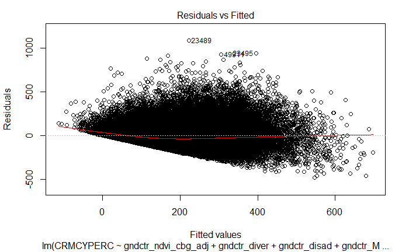

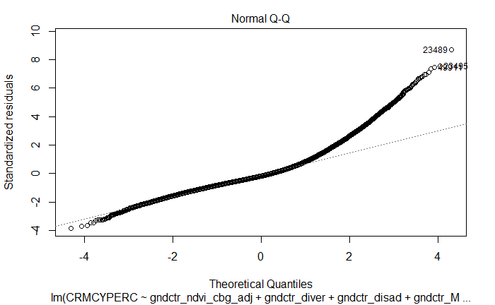

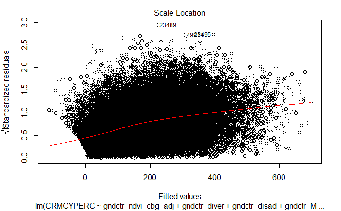

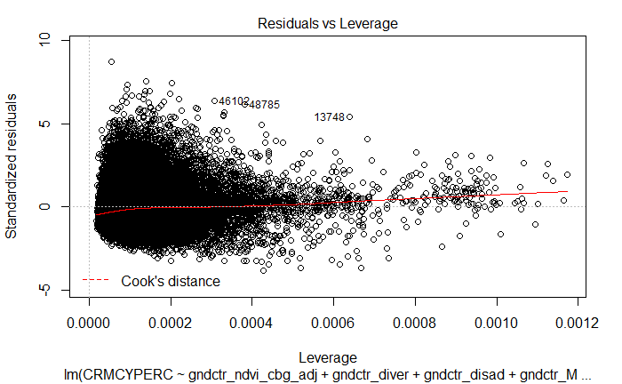

From this we can see some heteroscidacity with residuals spreading out at higher fitted values. QQ also shows some non-normalness. So obviously a linear regression isn’t going to cut it.

### Multilevel Models

```r
mod_2a <- lmer(CRMCYPERC ~ gndctr_ndvi_cbg_adj + (1|city_st), data = df)
mod_2b <- lmer(CRMCYPERC ~ gndctr_ndvi_cbg_adj + (1|city_st), data = df_urban)
screenreg(list(mod_2a, mod_2b))
```

```
========================================================
                          Model 1         Model 2
--------------------------------------------------------
(Intercept)                   154.60 ***      154.85 ***
                               (6.29)          (6.33)
gndctr_ndvi_cbg_adj           -35.65 ***      -35.71 ***
                               (0.61)          (0.62)
--------------------------------------------------------
AIC                        781256.90       769928.20
BIC                        781293.04       769964.29
Log Likelihood            -390624.45      -384960.10
Num. obs.                   62086           61183
Num. groups: city_st          301             301
Var: city_st (Intercept)    11755.35        11867.41
Var: Residual               16709.09        16713.97
========================================================
*** p < 0.001, ** p < 0.01, * p < 0.05
```

Big change in the effect of NDVI when we account for cities. Now it is negative and much larger. Model 1 is all cbg and model 2 is just urban. Let’s look at the plots.

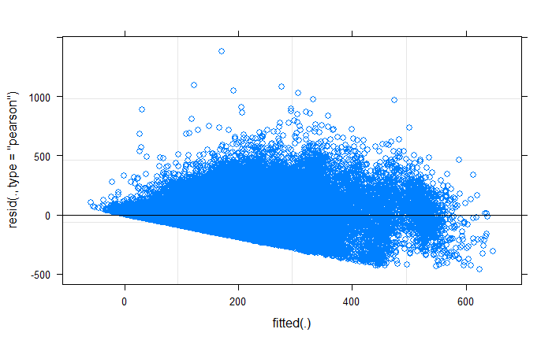

```r
plot(mod_2a)
```

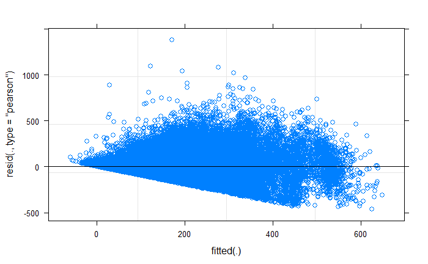

```r
plot(mod_2b)
```

There definitely is a pattern. What could be the cause if that?

Carry on with level 1 covariates.

```r
mod_3a <- lmer(CRMCYPERC ~ gndctr_ndvi_cbg_adj + gndctr_diver + gndctr_disad + gndctr_MedHHinc000 + gndctr_logpopden + gndctr_U18 + (1|city_st), data = df)
mod_3b <- lmer(CRMCYPERC ~ gndctr_ndvi_cbg_adj + gndctr_diver + gndctr_disad + gndctr_MedHHinc000 + gndctr_logpopden + gndctr_U18 + (1|city_st), data = df_urban)
screenreg(list(mod_2a, mod_2b, mod_3a, mod_3b), custom.model.names = c("all cbg", "urban", "all cbg", "urban"))
```

[output not shown]

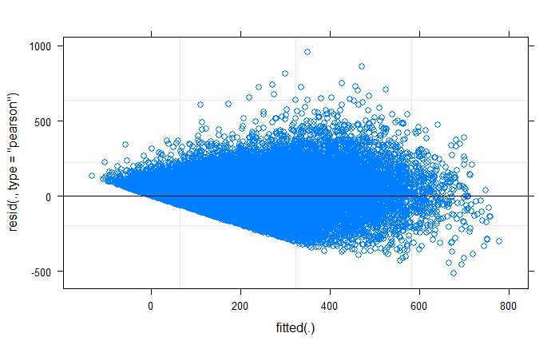

```r
plot(mod_3a)
```

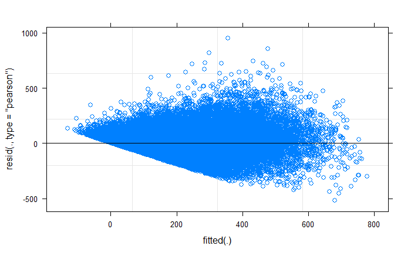

```r
plot(mod_3b)
```

Interesting, no real change there, still an issue present.

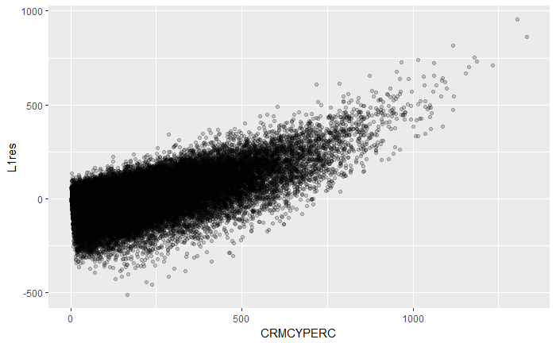

```r
L1resid <- resid(mod_3a)
t <- mod_3a@frame
t$L1res <-  resid(mod_3a)
# head(t)
t %>% ggplot(aes(CRMCYPERC, L1res)) + geom_point(alpha = .2)
```

Here with crime against the residuals you can see that the higher the crime index the higher the residual.

```r
mod_4a <- lmer(CRMCYPERC ~ gndctr_ndvi_cbg_adj + gndctr_diver + gndctr_disad + gndctr_MedHHinc000 + gndctr_logpopden+ (gndctr_ndvi_cbg_adj|city_st), data = df)
mod_4b <- lmer(CRMCYPERC ~ gndctr_ndvi_cbg_adj + gndctr_diver + gndctr_disad + gndctr_MedHHinc000 + gndctr_logpopden + (gndctr_ndvi_cbg_adj|city_st), data = df_urban)
screenreg(list(mod_4a, mod_4b), custom.model.names = c("all cbg", "urban"))
```

```
============================================================================
                                              all cbg         urban
----------------------------------------------------------------------------
(Intercept)                                       166.06 ***      165.47 ***
                                                   (5.39)          (5.40)
gndctr_ndvi_cbg_adj                               -25.87 ***      -25.48 ***
                                                   (1.79)          (1.81)
gndctr_diver                                      -34.80 ***      -35.05 ***
                                                   (2.60)          (2.62)
gndctr_disad                                      100.49 ***      100.64 ***
                                                   (0.78)          (0.78)
gndctr_MedHHinc000                                 -0.39 ***       -0.40 ***
                                                   (0.02)          (0.02)
gndctr_logpopden                                  -29.74 ***      -32.52 ***
                                                   (0.57)          (0.61)
----------------------------------------------------------------------------
AIC                                            717454.23       707341.22
BIC                                            717544.19       707431.04
Log Likelihood                                -358717.11      -353660.61
Num. obs.                                       59647           58808
Num. groups: city_st                              301             301
Var: city_st (Intercept)                         8412.99         8451.39
Var: city_st gndctr_ndvi_cbg_adj                  765.80          778.18
Cov: city_st (Intercept) gndctr_ndvi_cbg_adj    -1755.01        -1791.01
Var: Residual                                    9506.06         9501.07
============================================================================
*** p < 0.001, ** p < 0.01, * p < 0.05
```

and look at that plot again…

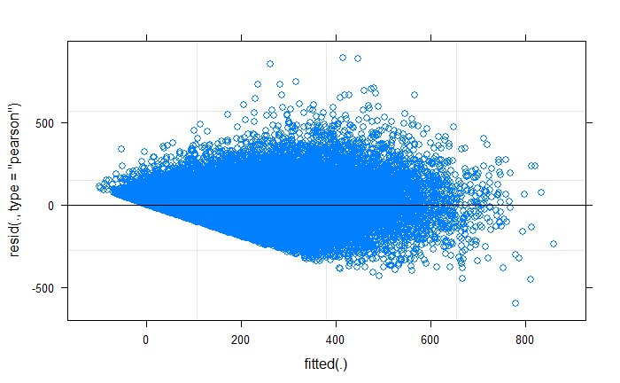

```r
plot(mod_4a)
```

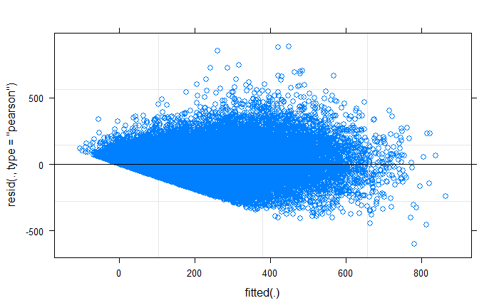

```r
plot(mod_4b)
```

Well, no change it seems. Something will need to be done to address that variance structure.

```r
car::leveneTest(t$L1res ~ t$city_st )
```

```
Levene's Test for Homogeneity of Variance (center = median)
         Df F value    Pr(>F)
group   300  42.874 < 2.2e-16 ***
      59346
---
Signif. codes:  0 ‘***’ 0.001 ‘**’ 0.01 ‘*’ 0.05 ‘.’ 0.1 ‘ ’ 1
```

With a signifinact Levene’s Test this confirms that there are differences in the variance across groups.

One solution is to log transform the response.

```r
mod_4c <- lmer(log(CRMCYPERC) ~ gndctr_ndvi_cbg_adj + gndctr_diver + gndctr_disad + gndctr_MedHHinc000 + gndctr_logpopden+ (gndctr_ndvi_cbg_adj|city_st), data = df)
screenreg(mod_4c)
```

```
===========================================================
                                              Model 1
-----------------------------------------------------------
(Intercept)                                        4.57 ***
                                                  (0.04)
gndctr_ndvi_cbg_adj                               -0.24 ***
                                                  (0.01)
gndctr_diver                                       0.26 ***
                                                  (0.02)
gndctr_disad                                       0.48 ***
                                                  (0.01)
gndctr_MedHHinc000                                -0.01 ***
                                                  (0.00)
gndctr_logpopden                                  -0.16 ***
                                                  (0.00)
-----------------------------------------------------------
AIC                                           119631.42
BIC                                           119721.38
Log Likelihood                                -59805.71
Num. obs.                                      59647
Num. groups: city_st                             301
Var: city_st (Intercept)                           0.43
Var: city_st gndctr_ndvi_cbg_adj                   0.02
Cov: city_st (Intercept) gndctr_ndvi_cbg_adj       0.01
Var: Residual                                      0.42
===========================================================
*** p < 0.001, ** p < 0.01, * p < 0.05
```

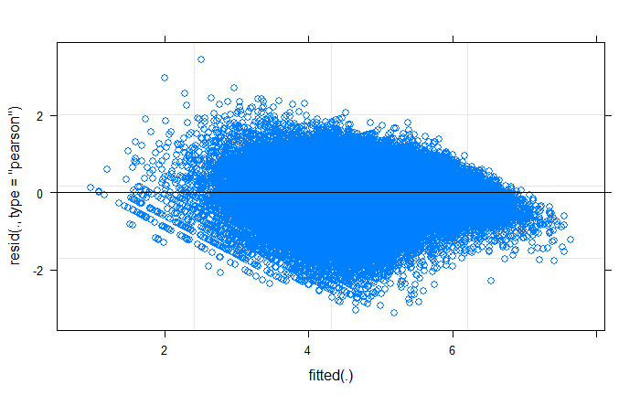

```r
plot(mod_4c)
```

```r
# car::leveneTest(residuals(mod_4c) ~ mod_4c@frame$city_st )
```

https://stats.stackexchange.com/questions/255546/test-homogeneity-in-lmer-models

| city_st | avgvar | varrange |
| --- | --- | --- |
| Murfreesboro_TN | 3.489090481 | 452.3191 |
| Little Rock_AR | 2.937700104 | 830.5894 |
| New Haven_CT | 2.772141508 | 486.9275 |
| Springfield_IL | 2.611349581 | 1317.7501 |
| Beaumont_TX | 2.064857845 | 546.7997 |
| Clarksville_TN | 1.958297396 | 435.8221 |
| Lansing_MI | 1.892667151 | 717.6247 |
| Springfield_MO | 1.888167197 | 536.6376 |
| Rockford_IL | 1.791133996 | 1026.7691 |
| Antioch_CA | 1.517545365 | 398.4559 |

[output cut: 291 more lines]

I can check the residuals to see if they are looking normally distributed despit the plot

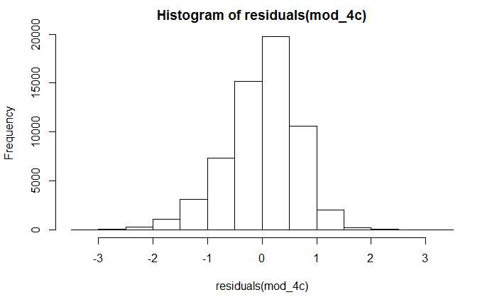

```r
hist(residuals(mod_4c))
```

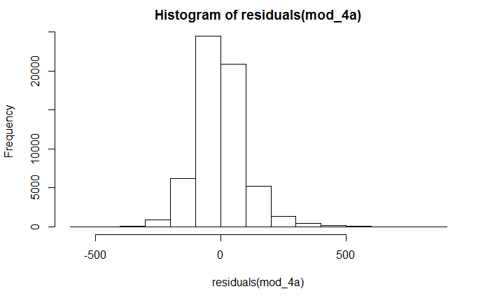

```r
hist(residuals(mod_4a))
```

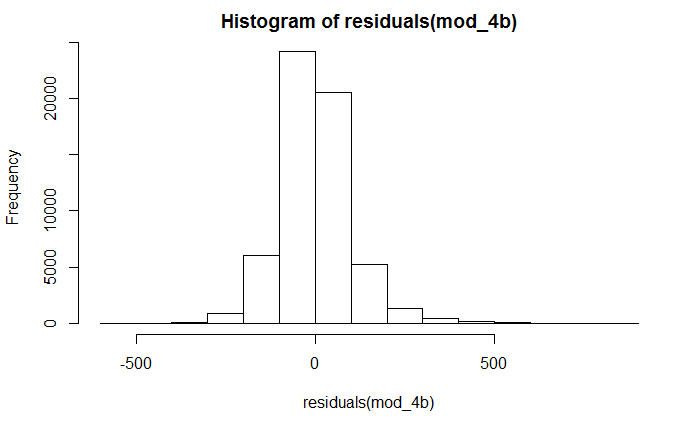

```r
hist(residuals(mod_4b))
```

```r
# curve(dnorm(x, mean=mean(residuals(mod_4c)), sd=sd(residuals(mod_4c))), add=TRUE)
# moments::jarque.test(residuals(mod_4c))
```